# NOAA Severe Weather Event Analysis (1950 - 2011)

16 August 2014

## Synopsis

The analysis shows the correlation between different types of events and their impact to health of the population. It also shows the economic impact of the various events and highlights the ones with the greatest consequences.

Based on analysis performed Tornados is responsible for the biggest impact to population health. Floods was responsible for the biggest economic impact overall, with droughts having the biggest impact if you any view it in terms of crop damage.

## About the data

The database contains data from 1950 to Nov 2011. Some data elements might not be compelete in earlier years due to lack of records.

Main data elements beign used in this analysis

| Data Column | Description |
| --- | --- |
| EVTYPE | Type of Events |
| FATALITIES | Number of fatalities that occured for that event |
| INJURIES | Number of injuries that occured for that event |
| PROPDMG | Property damage in USD |
| PROPDMGEXP | Propery Damage magnitude (millions, thousands,…). further information in Storm Data Documentation (2.7) |
| CROPDMG | Crop damage in USD |
| CROPDMGEXP | Crop Damage magnitude (millions, thousands,…).further information in Storm Data Documentation (2.7) |

Further Documentation:

National Weather Service Storm Data Documentation

National Climatic Data Center Storm Events FAQ

## Data Processsing

```r
require(plyr)
```

```r
require(ggplot2)
require(reshape2)
```

### Load dataset

load the data from the compressed file and do some basic checks

```r
filename.zip <- "repdata-data-StormData.csv.bz2"

if (!file.exists(filename.zip))
{
        file.url <- "https://d396qusza40orc.cloudfront.net/repdata%2Fdata%2FStormData.csv.bz2"
        file.download(file.url,file.zip,method="curl")
}
data <- read.csv(bzfile(filename.zip))
```

Now that the data is loaded we can do some basic checks to ensure data is loaded correctly and is usable in our further analysis.

```r
dim(data)
```

```
## [1] 902297     37
```

```r
##peek at the top rows of the dataset
head(data)
```

```
##   STATE__           BGN_DATE BGN_TIME TIME_ZONE COUNTY COUNTYNAME STATE
## 1       1  4/18/1950 0:00:00     0130       CST     97     MOBILE    AL
## 2       1  4/18/1950 0:00:00     0145       CST      3    BALDWIN    AL
## 3       1  2/20/1951 0:00:00     1600       CST     57    FAYETTE    AL
## 4       1   6/8/1951 0:00:00     0900       CST     89    MADISON    AL
## 5       1 11/15/1951 0:00:00     1500       CST     43    CULLMAN    AL
## 6       1 11/15/1951 0:00:00     2000       CST     77 LAUDERDALE    AL
##    EVTYPE BGN_RANGE BGN_AZI BGN_LOCATI END_DATE END_TIME COUNTY_END
## 1 TORNADO         0                                               0
## 2 TORNADO         0                                               0
## 3 TORNADO         0                                               0
## 4 TORNADO         0                                               0
## 5 TORNADO         0                                               0
## 6 TORNADO         0                                               0
##   COUNTYENDN END_RANGE END_AZI END_LOCATI LENGTH WIDTH F MAG FATALITIES
```

[output cut: 20 more lines]

```r
##look at the datatypes
sapply(data, class)
```

```
##    STATE__   BGN_DATE   BGN_TIME  TIME_ZONE     COUNTY COUNTYNAME
##  "numeric"   "factor"   "factor"   "factor"  "numeric"   "factor"
##      STATE     EVTYPE  BGN_RANGE    BGN_AZI BGN_LOCATI   END_DATE
##   "factor"   "factor"  "numeric"   "factor"   "factor"   "factor"
##   END_TIME COUNTY_END COUNTYENDN  END_RANGE    END_AZI END_LOCATI
##   "factor"  "numeric"  "logical"  "numeric"   "factor"   "factor"
##     LENGTH      WIDTH          F        MAG FATALITIES   INJURIES
##  "numeric"  "numeric"  "integer"  "numeric"  "numeric"  "numeric"
##    PROPDMG PROPDMGEXP    CROPDMG CROPDMGEXP        WFO STATEOFFIC
##  "numeric"   "factor"  "numeric"   "factor"   "factor"   "factor"
##  ZONENAMES   LATITUDE  LONGITUDE LATITUDE_E LONGITUDE_    REMARKS
##   "factor"  "numeric"  "numeric"  "numeric"  "numeric"   "factor"
##     REFNUM
##  "numeric"
```

We are interested in the EVTTYPE column. Lets take a look at the different types of events in the dataset and ensure it is clean.

```r
##look at unique event types
unique(sort(data$EVTYPE))
```

```
##   [1]    HIGH SURF ADVISORY           COASTAL FLOOD
##   [3]  FLASH FLOOD                    LIGHTNING
##   [5]  TSTM WIND                      TSTM WIND (G45)
##   [7]  WATERSPOUT                     WIND
##   [9] ?                              ABNORMAL WARMTH
##  [11] ABNORMALLY DRY                 ABNORMALLY WET
##  [13] ACCUMULATED SNOWFALL           AGRICULTURAL FREEZE
##  [15] APACHE COUNTY                  ASTRONOMICAL HIGH TIDE
##  [17] ASTRONOMICAL LOW TIDE          AVALANCE
##  [19] AVALANCHE                      BEACH EROSIN
##  [21] Beach Erosion                  BEACH EROSION
##  [23] BEACH EROSION/COASTAL FLOOD    BEACH FLOOD
##  [25] BELOW NORMAL PRECIPITATION     BITTER WIND CHILL
##  [27] BITTER WIND CHILL TEMPERATURES Black Ice
##  [29] BLACK ICE                      BLIZZARD
```

[output cut: 479 more lines]

```r
##summary(sort(data$EVTYPE))
```

There are lots of duplicate event types and requires a cleanup. Some issues include spelling errors and plurals of event descriptions. We have chosen a basic approach for now to cleanup the event types but a text mining or non systematic approach can be applied to do further cleanup of the data.

```r
data$EVTYPE <- toupper(data$EVTYPE) ##make all uppercase
data$EVTYPE <- gsub("[\\]", " ", data$EVTYPE)  ##remove / and \ chars
data$EVTYPE <- gsub("[/]", " ", data$EVTYPE)  ##remove / and \ chars
data$EVTYPE <- gsub("[-]", " ", data$EVTYPE)  ##remove -
data$EVTYPE <- gsub("^\\s+|\\s+$", "", data$EVTYPE)  ##remove leading and trailing spaces
##Some Manual cleanup
data$EVTYPE <- gsub("TSTM WIND", "THUNDERSTORM WIND", data$EVTYPE)  ##change evtn type
data$EVTYPE <- gsub("THUNDERSTORM WINDS", "THUNDERSTORM WIND", data$EVTYPE)  ##rhange evtn type

data$EVTYPE <- gsub("HIGH WINDS", "HIGH WIND", data$EVTYPE)  ##change evtn type
```

Lets check the values for the Population Health.

```r
summary(data$INJURIES)
```

```
##    Min. 1st Qu.  Median    Mean 3rd Qu.    Max.
##     0.0     0.0     0.0     0.2     0.0  1700.0
```

```r
summary(data$FATALITIES)
```

```
##    Min. 1st Qu.  Median    Mean 3rd Qu.    Max.
##       0       0       0       0       0     583
```

No unexpected values in the FATALITIES or INJURIES data. Lets check the values for the PROPERY and CROP Damage

```r
summary(data$PROPDMG)
```

```
##    Min. 1st Qu.  Median    Mean 3rd Qu.    Max.
##       0       0       0      12       0    5000
```

```r
summary(data$CROPDMG)
```

```
##    Min. 1st Qu.  Median    Mean 3rd Qu.    Max.
##     0.0     0.0     0.0     1.5     0.0   990.0
```

```r
##checking and cleanup of exponent part
unique(data$PROPDMGEXP)
```

```
##  [1] K M   B m + 0 5 6 ? 4 2 3 h 7 H - 1 8
## Levels:  - ? + 0 1 2 3 4 5 6 7 8 B h H K m M
```

```r
unique(data$CROPDMGEXP)
```

```
## [1]   M K m B ? 0 k 2
## Levels:  ? 0 2 B k K m M
```

```r
data$PROPDMGEXP <- toupper(data$PROPDMGEXP)
data$CROPDMGEXP <- toupper(data$CROPDMGEXP)
```

Lets create a function to apply the different types of exponents to the amounts. Some data Quality Issues exist in the EXP data. Our assumption is that the value are invalid and will not require any adjustments.

```r
##create a function to apply function
Value.Cleanup <- function(value,exp){
        ##Assume all except K,M,B,H are invalid
        if (exp=='H'){ ## Hunderds
                value * 10^2
        }
        else if (exp=='K'){ ## thousands
                value * 10^3
        }
        else if (exp=='M'){## millions
                value * 10^6
        }
        else if (exp=='B'){## Billions
                value * 10^9
        }
        else {##Assume the rest is bad data Quality
             value * 10^0
        }
}
data$PROPDMG.CLEAN <- mapply(Value.Cleanup, data$PROPDMG, data$PROPDMGEXP)
data$CROPDMG.CLEAN <- mapply(Value.Cleanup, data$CROPDMG, data$CROPDMGEXP)
data$TOTALDMG <- data$PROPDMG.CLEAN + data$CROPDMG.CLEAN
```

## Results

Across the United States, which types of events (as indicated in the EVTYPE variable) are most harmful with respect to population health?

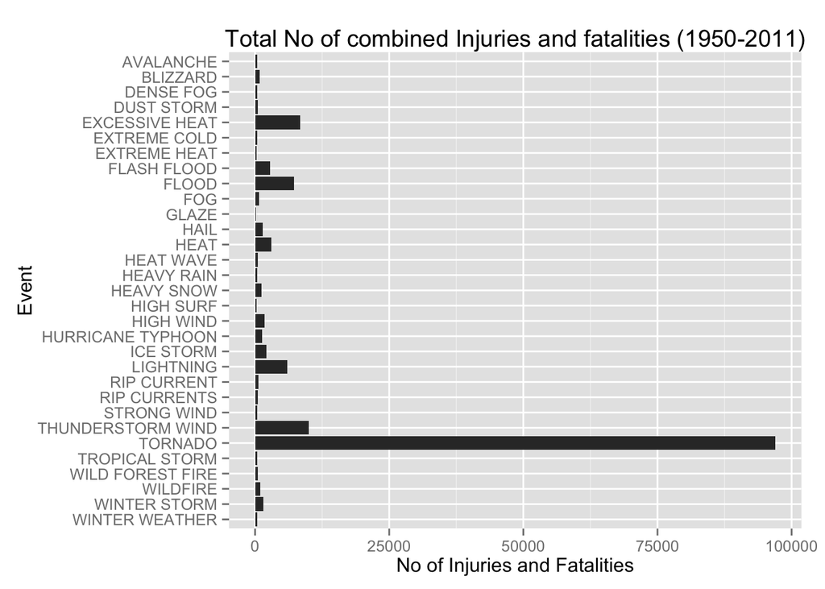

```r
data$HEALTH  <-  data$INJURIES + data$FATALITIES
cols.summary <- c("INJURIES","FATALITIES","HEALTH","PROPDMG.CLEAN","CROPDMG.CLEAN","TOTALDMG")
data.summary <- ddply(data, .(EVTYPE), colwise(sum, cols.summary))

##lets get all events that is higher then the mean
data.mean <- mean(data.summary$HEALTH)
data.summary.plot <- subset(data.summary,HEALTH >= data.mean)
ggplot(data=data.summary.plot, aes(x=EVTYPE, y=HEALTH), fill="l") +
     geom_bar( stat="identity") +
        coord_flip() +
        scale_x_discrete(limits=rev(data.summary.plot$EVTYPE), name="Event") +
        ylab("No of Injuries and Fatalities") +
        ggtitle('Total No of combined Injuries and fatalities (1950-2011)')
```

```r
row.mean <- nrow(data.summary.plot)
```

There are 31 events that is above the mean of the health metric (injuries + fatalities).

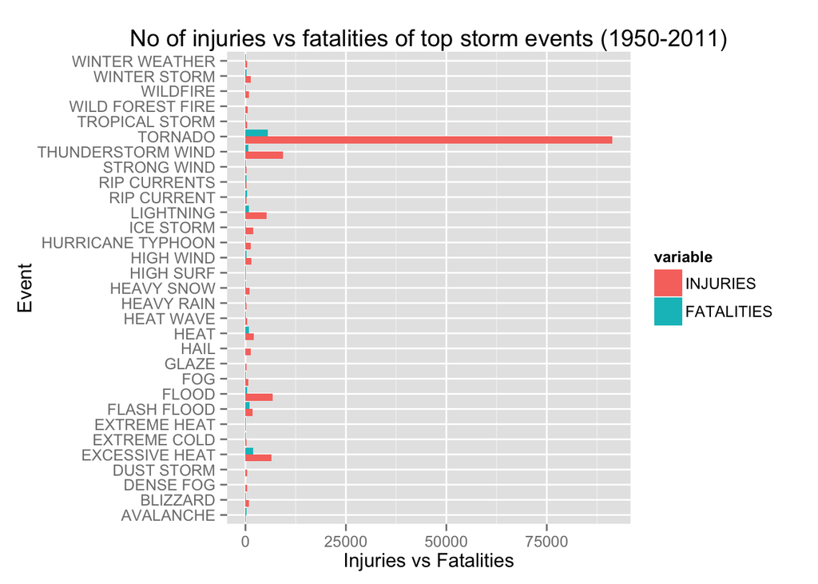

```r
##Melt data frame to get a draw a bar graph with the comparisions
data.summary.plot.melt <- melt(data.summary.plot[,c("EVTYPE","INJURIES","FATALITIES")], id="EVTYPE")

qplot(factor(EVTYPE),
      data=data.summary.plot.melt ,
      geom="bar",
      fill=variable,
      weight=value,
      position='dodge'
      ) +
        coord_flip() +
        scale_size_area() +
        ylab("Injuries vs Fatalities") +
        xlab("Event") +
        ggtitle('No of injuries vs fatalities of top storm events (1950-2011)')
```

Most of the injuries and fatalities occured with a tornado event. Across the United States, which types of events have the greatest economic consequences? Lets compare the top 10 event that caused the most damage (total of crop and property).

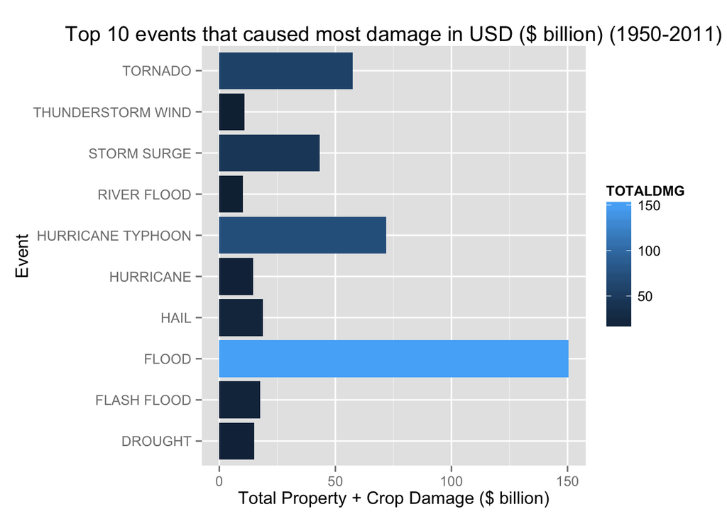

```r
##Get top 10 of each Health metric
data.summary.plot.econ <- head(data.summary[order(data.summary$TOTALDMG, decreasing=TRUE), ], 10)
data.summary.plot.econ$TOTALDMG <- data.summary.plot.econ$TOTALDMG / 10^9
##Do Plot

qplot(factor(EVTYPE),
      data=data.summary.plot.econ,
      geom="bar",
      fill=TOTALDMG,
      weight=TOTALDMG,
      ) +
        coord_flip() +
        scale_size_area() +
        ylab("Total Property + Crop Damage ($ billion)") +
        xlab("Event") +
        ggtitle('Top 10 events that caused most damage in USD ($ billion) (1950-2011)')
```

```r
##Data
```

The data table of the economic consequences and that is depicted in the bar graph above in billions USD

```r
data.summary.plot.econ$PROPERTY_DAMAGE<- data.summary.plot.econ$PROPDMG.CLEAN / 10^9
data.summary.plot.econ$CROP_DAMAGE <- data.summary.plot.econ$CROPDMG.CLEAN / 10^9
data.summary.plot.econ[,c("EVTYPE","PROPERTY_DAMAGE","CROP_DAMAGE")]
```

```
##                EVTYPE PROPERTY_DAMAGE CROP_DAMAGE
## 145             FLOOD         144.658    5.661968
## 352 HURRICANE TYPHOON          69.306    2.607873
## 732           TORNADO          56.937    0.414953
## 570       STORM SURGE          43.324    0.000005
## 199              HAIL          15.732    3.025954
## 130       FLASH FLOOD          16.141    1.421317
## 76            DROUGHT           1.046   13.972566
## 343         HURRICANE          11.868    2.741910
## 656 THUNDERSTORM WIND           9.712    1.159505
## 504       RIVER FLOOD           5.119    5.029459
```